# Simulating disease transmission (Part 2)

Hector Marina

[figure not shown]

## Introduction

This practical begins by estimating transmission and recovery parameters from disease data, then expands the previously introduced compartmental model into an individual-based model in which the infection history of each animal is followed explicitly, and finally introduces spatial transmission models where infection risk depends on the distance between individuals.

1. Model Parameterization
2. Individual-based models
3. Spatial transmission models

### Required packages

```r
library(MASS)
```

## Model Parameterization

To learn how transmission-model parameters can be estimated from longitudinal disease data, we will first simulate an epidemic using the stochastic compartmental model introduced in the previous practical. Because the values of $\beta$ and $\gamma$ used to generate the data are known, we can then test whether they can be recovered from the simulated observations.

The example resembles longitudinal mastitis surveillance such as that described by [Woudstra et al. (2023)](https://doi.org/10.3168/JDS.2022-22942), where animals are repeatedly sampled to determine whether a mastitis-causing pathogen is present. For simplicity, animals positive for a selected pathogen will be considered infected ($I$), whereas pathogen-negative animals will be considered susceptible ($S$).

We begin by fixing a random seed to make the stochastic simulation reproducible.

```r
set.seed(123)
```

Define the simulation period, transmission rate ($\beta$), recovery rate ($\gamma$), and vectors used to store the number of susceptible ($S$) and infected ($I$) individuals and the infection and recovery events occurring each day.

```r
nsteps=100
time  =1:nsteps

beta  = 0.3     # Rate of infection
gamma = 1/14    # Rate of recovery (14 days to recover)

S=I=numeric(nsteps)    # Susceptible and Infected compartments info
new_infections=new_recoveries=numeric(nsteps-1) # New infections and recoveries
```

Set the initial population conditions: susceptible individuals (995/1000), infectious individuals (5/1000), and recovered individuals (0/1000).

```r
N=1000
S[1]=N - 5
I[1]=5
```

The simulated disease follows an SIS ($S \rightarrow I \rightarrow S$) structure. Susceptible individuals become infected according to the transmission rate $\beta$, whereas infected individuals recover at rate $\gamma$ and immediately become susceptible again:

$$\frac{dS}{dt}=-\beta\frac{SI}{N}+\gamma I$$

$$\frac{dI}{dt}=\beta\frac{SI}{N}-\gamma I.$$

At each time step, the expected numbers of infection and recovery events are calculated and the actual numbers are sampled from negative-binomial distributions.

```r
for (t in 1:(nsteps-1)) {
  # New infections
  mu_inf=beta * (I[t] * S[t]) / N
  new_infections[t]=min(MASS::rnegbin(1, mu = mu_inf, theta = 1), S[t])

  # New recoveries
  mu_cure=gamma * I[t]
  new_recoveries[t]=min(MASS::rnegbin(1, mu = mu_cure, theta = 1), I[t])

  # Update compartments
  S[t+1] <- S[t] - new_infections[t] + new_recoveries[t]
  I[t+1] <- I[t] + new_infections[t] - new_recoveries[t]
}
```

We can now construct a dataset resembling longitudinal disease surveillance. For each day, the dataset contains the numbers of susceptible and infected individuals and the numbers of new infections and recoveries observed during the following time step.

```r
inf_df=data.frame(
  time = time[-nsteps],
  S_time = S[-nsteps],
  I_time = I[-nsteps],
  new_infections = new_infections,
  new_recoveries = new_recoveries
)
```

The resulting stochastic epidemic can be visualized as the number of susceptible and infected individuals over time.

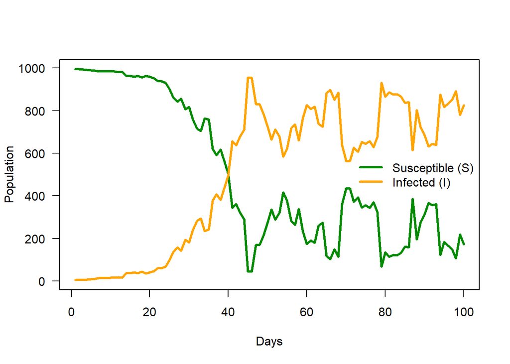

```r
plot(time, S, type = "l", lwd = 3, col = "green4", ylim = c(0, N),
     xlab = "Days", ylab = "Population",las = 1)
lines(time, I, lwd = 3, col = "orange")
legend("right", legend = c("Susceptible (S)","Infected (I)"),
         col = c("green4", "orange"), lwd = 3, bty = "n")
```

### Estimating the transmission rate ($\beta$)

For the SIS model, the expected number of new infections during a time step is

$$E(\text{new infections}_t)
=
\beta\frac{S_tI_t}{N}$$

Taking logarithms gives:

$$\log E(\text{new infections}_t)
=
\log(\beta)
+
\log\left(\frac{S_tI_t}{N}\right)$$

Therefore, $\log(S_tI_t/N)$ can be included as an offset in a count regression, and the intercept provides an estimate of $\log(\beta)$.

Here we use negative-binomial regression to allow the number of new infections to be overdispersed.

```r
model_foi=MASS::glm.nb(new_infections ~ 1 +
                         offset(log(inf_df$S_time*inf_df$I_time/N)), data = inf_df)
beta_hat=exp(coef(model_foi)[1])

# Output
cat("Estimated transmission rate (beta):", beta_hat, "\n")
```

```
## Estimated transmission rate (beta): 0.3133357
```

```r
cat("True transmission rate (beta):", beta, "\n\n")
```

```
## True transmission rate (beta): 0.3
```

> **NOTE — Why use an offset?**  
> The mechanistic model already specifies that new infections are proportional to $SI/N$. Including $\log(SI/N)$ as an offset fixes its regression coefficient to 1. The regression therefore estimates $\log(\beta)$ rather than estimating a new relationship between $SI/N$ and the number of infections.

### Estimating the recovery rate ($\gamma$)

The same principle can be applied to recovery events. The expected number of recoveries during a time step is

$$E(\text{new recoveries}_t)=\gamma I_t$$

Taking logarithms gives

$$\log E(\text{new recoveries}_t)
=
\log(\gamma)+\log(I_t)$$

Thus, $\log(I_t)$ is used as the offset and the regression intercept estimates $\log(\gamma)$.

```r
# Model 2: Estimate cure rate (gamma)
model_cure=glm.nb(new_recoveries ~ 1 + offset(log(I_time)), data = inf_df)
gamma_hat =exp(coef(model_cure)[1])

cat("Estimated cure rate (gamma):", gamma_hat, "\n")
```

```
## Estimated cure rate (gamma): 0.07783771
```

```r
cat("True cure rate (gamma):", gamma, "\n")
```

```
## True cure rate (gamma): 0.07142857
```

The estimated values can now be compared with the known values used to generate the simulated epidemic. Differences are expected because the epidemic is stochastic and only one realization of the transmission process has been observed.

### Understanding the transmission offset

The transmission exposure

$$\frac{SI}{N}$$

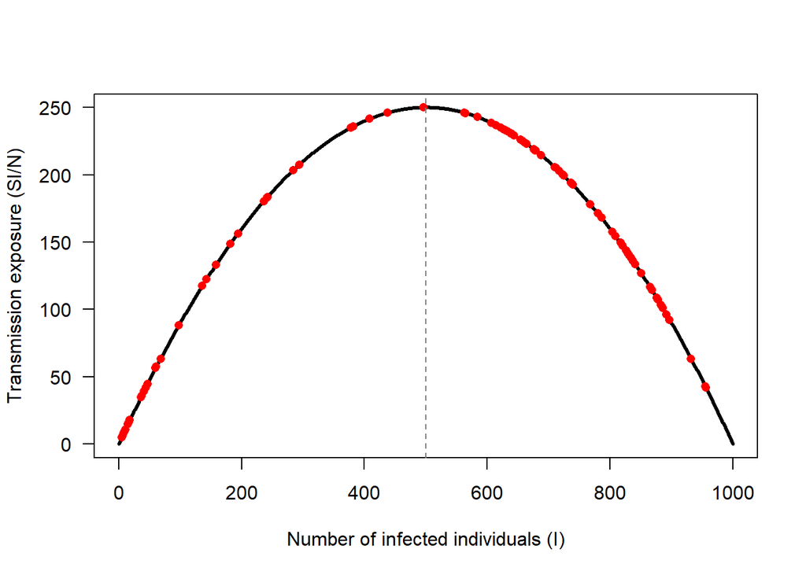

```r
N=1000    # Total number of individuals
x=0:1000

S_test=N-x  # Susceptible individuals
I_test=x    # Infected individuals

plot(I_test,S_test*I_test/N,
     type="l",lwd=3,las=1,
     xlab="Number of infected individuals (I)",
     ylab="Transmission exposure (SI/N)")

points(inf_df$I_time,  # Add simulated values to the distribution
       inf_df$S_time*inf_df$I_time/N, pch=16, col="red")

abline(v=N/2,lty=2,col="grey50")
```

The transmission exposure $SI/N$ is largest when the population contains equal numbers of susceptible and infected individuals ($S=I=N/2$). This does **not** mean that the individual risk of infection is maximal at this point. Instead, it means that the population contains the largest combination of susceptible individuals available to become infected and infected individuals capable of transmitting infection.

Accounting for this changing exposure allows $\beta$ to represent the transmission rate independently of changes in the numbers of susceptible and infected individuals.

### Exercise 1: How accurately can we recover the model parameters?

We generated the epidemic using known values of $\beta$ and $\gamma$. Now investigate under which conditions the regression models are able to recover these parameters accurately.

Modify one element at a time, repeat the stochastic simulation, and compare the estimated values ($\hat{\beta}$ and $\hat{\gamma}$) with the true values used to generate the epidemic.

1. *Transmission rate (*$\beta$).  
   Simulate epidemics using lower and higher values of `beta`. How does the transmission rate affect the accuracy and variability of $\hat{\beta}$?
2. *Recovery rate (*$\gamma$).  
   Modify `gamma` to generate shorter or longer infectious periods ($1/\gamma$). How does this affect the estimation of both $\beta$ and $\gamma$?
3. *Population size (*$N$).  
   Compare small and large populations (e.g. `N = 100`, `500`, and `1000`). When changing $N$, try to maintain a similar initial prevalence (`I[1]/N`) to make the scenarios comparable.
4. *Duration of surveillance.*  
   Compare short and long observation periods (e.g. 30, 100, and 365 days). Does having more observations improve parameter estimation?

For each scenario, compare the estimated and true parameters. You can quantify the estimation error as:

$$\text{Relative error}=
\frac{|\hat{\beta}-\beta|}{\beta}\times100$$

and equivalently for $\gamma$.

Finally, based on your simulations, *under which conditions is parameter estimation most reliable?* Consider:

- Is a *large or small population* preferable?
- Are *high or low transmission rates* easier to estimate?
- Are *short or long infectious periods* more informative?
- Is a *short or long surveillance period* preferable?
- What happens when transmission is so low that very few infections occur or the infection disappears?

> *NOTE:* In this exercise we fitted a negative-binomial regression. Kirkeby et al. reported that negative-binomial regression estimates were very similar to those from Poisson regression, while it failed to estimate transmission rates in many simulations with sparse transmission events.

## Individual-based models

In the previous models, individuals were represented collectively by the number of animals in each compartment. In an individual-based model (IBM), each individual is represented explicitly and its epidemiological state is followed through time.

Here, we will implement an $ S I R S$. $\beta$ determines transmission between connected susceptible and infected individuals, $\gamma$ determines recovery, and $\theta$ determines the loss of immunity. Therefore, each animal can be in one of three next states:

- `0` = Susceptible ($S$)
- `1` = Infected ($I$)
- `2` = Recovered ($R$)

Similarly to the compartmental models, in this example transmission will be possible between all individuals included in the simulation.

> **NOTE:** In this discrete-time individual-based model, $\beta$, $\gamma$, and $\theta$ are used as *daily transition probabilities*. In particular, $\beta$ represents the probability of transmission during a contact with an infected individual. Its interpretation is therefore different from the previous compartmental models.

Lets fix a random seed again to make the simulation reproducible.

```r
set.seed(123)
```

### Define the population and transmission parameters

We first define the number of individuals, duration of the simulation, transition probabilities, and average number of contacts per individual.

```r
nsteps=100
N=100

beta=0.01   # S -> I
gamma=1/7   # I -> R
theta=1/14  # R -> S
```

### Represent each individual explicitly

The epidemiological state [$S=0$, $I=1$, and $R=2$] of every individual is stored in a matrix. Rows represent individuals and columns represent days.

```r
Status=matrix(0,nrow=N,ncol=nsteps)
```

Initially, every animal is susceptible except of five individual, which will be initially infected.

```r
infected=sample(1:N,5)
Status[infected,1]=1
```

This matrix is one of the main differences between compartmental and individual-based models. Rather than storing only the total number of infected animals, we retain the *identity and disease history of every individual*.

### Simulate disease progression

We can now simulate the epidemic one day at a time. For this initial approach, we will assume a homogeneous-mixing framework, whereby each individual comes into contact with every other individual in the population.

At the beginning of each day, individuals retain their previous epidemiological state. Three processes can then occur:

1. Recovered individuals may lose immunity ($R\rightarrow S$);
2. Infected individuals may recover ($I\rightarrow R$);
3. susceptible individuals may become infected through contact with infectious individuals ($S\rightarrow I$).

```r
for(i in 1:(nsteps-1)){
  # 1. Loss of immunity: R -> S
  R_S=which(Status[,i]==2)
  if(length(R_S)>0){
    LoI=rbinom(length(R_S), size=1, prob=theta)==1
    Status[R_S[ LoI],i+1]=0
    Status[R_S[!LoI],i+1]=2
  }

  # 2. Gain of Immunity: I -> R
  I_R=which(Status[,i]==1)
  if(length(I_R)>0){
    GoI=rbinom(length(I_R), size=1, prob=gamma)==1
    Status[I_R[ GoI],i+1]=ifelse(theta<1,2,0)
    Status[I_R[!GoI],i+1]=1
  }

  # 3. Transmission of Infection: S -> I
  I=which(Status[,i]==1)
  S=which(Status[,i]==0)

  if(length(I)>0 & length(S)>0){
    p_inf=1-(1-beta)^length(I)
    ToI=rbinom(length(S), size=1, prob=p_inf)==1
    Status[S[ToI],i+1]=1
  }
}
```

For a susceptible individual with $k$ infectious contacts, the probability of avoiding infection from all contacts is

$$(1-\beta)^k.$$

Therefore, the probability of becoming infected during that day is

$$P(\text{infection})=1-(1-\beta)^k.$$

This illustrates an important advantage of individual-based models: animals with different contact patterns can experience different infection risks even when they have the same biological susceptibility.

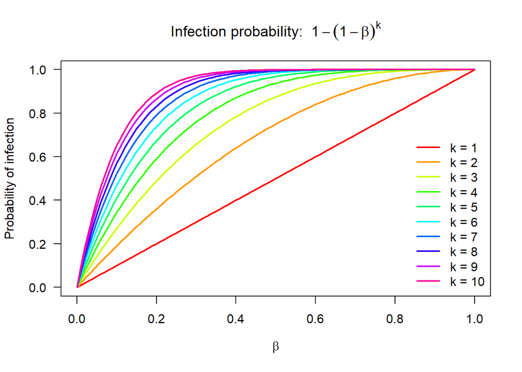

```r
x=seq(0, 1, by = 0.01)  # Theoretical range of Beta values
k_vals=1:10             # Number of infections contacts
cols=rainbow(length(k_vals))

plot(x, 1 - (1 - x)^1, type = "l",
     lwd = 2,
     col = cols[1],
     ylim = c(0, 1),
     xlab = expression(beta),
     ylab = "Probability of infection",
     main = expression("Infection probability: " ~ 1-(1-beta)^k),
     las = 1)

for(i in 2:length(k_vals)){
  lines(x, 1 - (1 - x)^k_vals[i], lwd = 2, col = cols[i])}

legend("bottomright", legend = paste("k =", k_vals),
       col = cols, lwd = 2, bty = "n")
```

### Visualize the epidemic

Although the simulation tracks every animal separately, we can summarize the individual states to obtain population-level epidemic curves.

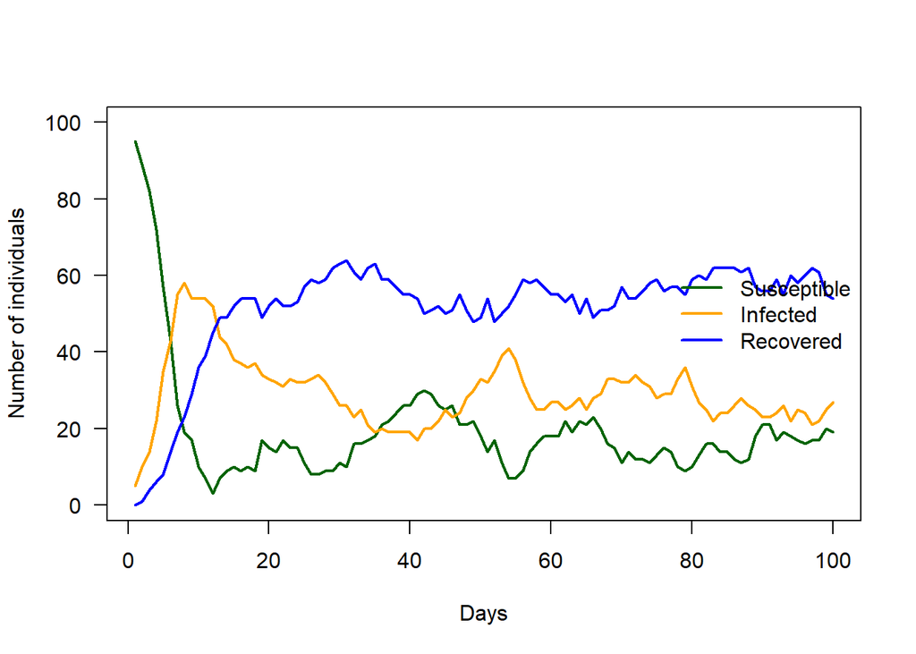

```r
S_total=colSums(Status==0)
I_total=colSums(Status==1)
R_total=colSums(Status==2)

plot(1:nsteps,S_total,type="l", col="darkgreen",
     lwd=2,  ylim=c(0,N), xlab="Days",
     ylab="Number of individuals", las=1)
lines(1:nsteps,I_total,col="orange",lwd=2)
lines(1:nsteps,R_total,col="blue"  ,lwd=2)

legend("right", legend=c("Susceptible","Infected","Recovered"),
       col=c("darkgreen","orange","blue"), lwd=2, bty="n")
```

Notice that the resulting curves look similar to those produced by compartmental models. However, these population-level curves are now **summaries of individual trajectories**, rather than the quantities directly simulated by the model.

### Follow a single individual

Because individual identity is retained, we can also investigate the epidemiological history of particular individuals.

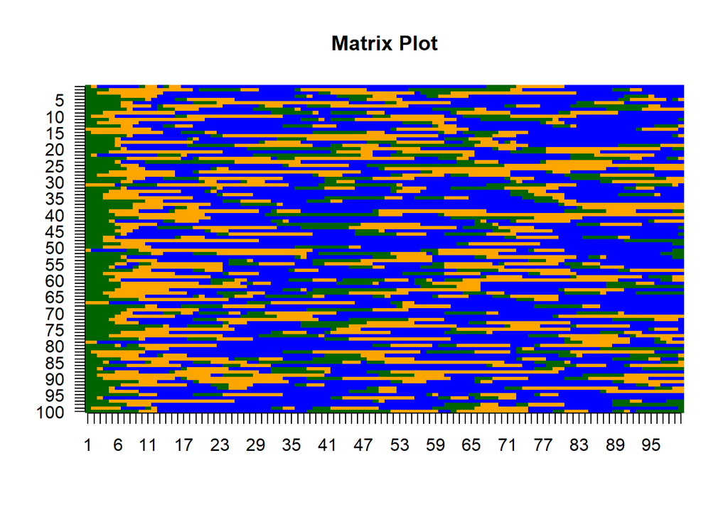

```r
if(theta<1){cols=c("darkgreen","orange","blue")}else{cols=c("darkgreen","orange")}
image(t(apply(Status, 2, rev)), col = cols, axes = FALSE,main = "Matrix Plot")
axis(1, at=seq(0, 1, length.out=ncol(Status)), labels=1:ncol(Status))
axis(2, at=seq(0, 1, length.out=nrow(Status)), labels=nrow(Status):1, las=1)
```

Unlike a compartmental model, we can therefore ask questions such as:

- How many times was an individual infected?
- How long did each infection last?
- Which individuals experienced the greatest exposure?
- Which contacts were responsible for transmission?

These types of individual-level questions are one of the main reasons for using individual-based models.

### Exercise 2: Exploring an individual-based transmission model

Use the individual-based model to investigate how disease dynamics depend on both **disease parameters** and **contact structure**.

Modify one parameter at a time and repeat several stochastic simulations.

1. *Transmission probability (*$\beta$).  
   Increase and decrease `beta`. How does the probability of transmission during a contact affect epidemic establishment, peak prevalence, and persistence?
2. *Recovery probability (*$\gamma$). Test different values of `gamma`. Remember that the expected infectious period is approximately $1/\gamma$. What happens when infected animals remain infectious for longer?
3. *Loss of immunity (*$\theta$). Compare different values of `theta`. What happens when recovered individuals rapidly become susceptible again? What type of compartmental structure does the individual-based model represent when $\theta=0$ or $\theta=1$?
4. *Population size.* Compare small and large populations while keeping approximately the same initial prevalence and mean number of contacts per individual.
5. *Probability of infection.*  
   Replace the probability of infection formula

   $$P(\text{infection})=1-(1-\beta)^k$$

   with a constant probability equal to $\beta$. What plausible scenario does this represent, and how does it affect disease transmission?
6. *Herd immunity.*  
   Introduce herd immunity by increasing the number of recovered/resistant ($R$) individuals at the beginning of the simulation (`Status[,1]`). How does this affect epidemic transmission and persistence?

## Spatial transmission models

In the previous individual-based model, every susceptible individual was exposed to the same number of infected individuals, independently of their location. However, disease transmission often depends on the spatial proximity between individuals.

We will now extend the individual-based model by assigning each individual a fixed spatial position $(x,y)$. Instead of assuming homogeneous mixing, the probability of transmission will decrease with the distance between susceptible and infected individuals.

### Define the spatial environment

Lets fix a random seed again to make the simulation reproducible.

```r
set.seed(123)
```

We will simulate the same SIRS structure used previously, but now individuals will be distributed within a two-dimensional area. `area_size` defines the length of each side of the simulated square environment, so `area_size = 100` creates a $100 \times 100$ spatial area, while `sigma` controls the spatial transmission range: smaller values make transmission decline rapidly with distance, whereas larger values allow infected individuals to influence susceptible individuals over greater distances.

```r
nsteps=100
N=100

beta=0.3   # S -> I
gamma=1/7   # I -> R
theta=1/14  # R -> S

area_size=100
sigma=10       # Spatial transmission range
```

Each individual is assigned a random position within a $100 \times 100$ spatial area.

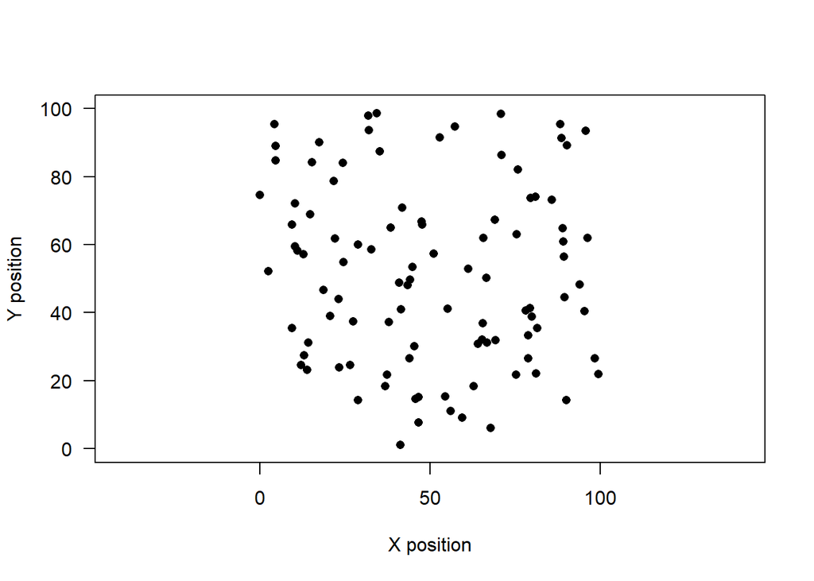

```r
x_pos=runif(N,0,area_size)
y_pos=runif(N,0,area_size)

plot(x_pos,y_pos, pch=16,
     xlab="X position",
     ylab="Y position",
     xlim=c(0,area_size), ylim=c(0,area_size),
     asp=1, las=1)
```

Then we estimate the distance between every pair of individuals from their spatial coordinates.

```r
Coordinates=cbind(x_pos,y_pos)
Distance=as.matrix(dist(Coordinates))
```

### Distance-dependent transmission

We assume that the contribution of an infected individual $j$ to the infection probability of a susceptible individual $i$ decreases exponentially with the distance between them:

$$p_{ij}=\beta e^{-d_{ij}/\sigma}$$

where $d_{ij}$ is the distance between the two individuals ($i$ and $j$) and $\sigma$ controls the spatial range of transmission.

At distance zero, the transmission probability is $\beta$. As distance increases, the probability progressively decreases.

> **NOTE:** $\sigma$ determines how rapidly transmission decreases with distance. Small values restrict transmission to nearby individuals, whereas large values allow infected individuals to influence susceptible individuals at greater distances.

If a susceptible individual is simultaneously exposed to several infected individuals, each infected individual contributes independently to its infection risk. The combined probability of infection is therefore

$$P_i(\text{infection})
=
1-\prod_{j=1}^{k}(1-p_{ij}).$$

This is similar to the probability used in the previous individual-based model,

$$1-(1-\beta)^k,$$

but now each infected individual can contribute a different transmission probability depending on its distance from the susceptible individual.

### Initialize the population

As before, the epidemiological state of every individual is stored in a matrix, and five initial infected individuals are defined in the population.

```r
Status_sp=matrix(0,nrow=N,ncol=nsteps)

infected=sample(1:N,5)
Status_sp[infected,1]=1
```

We can visualize the initial spatial distribution of susceptible and infected individuals.

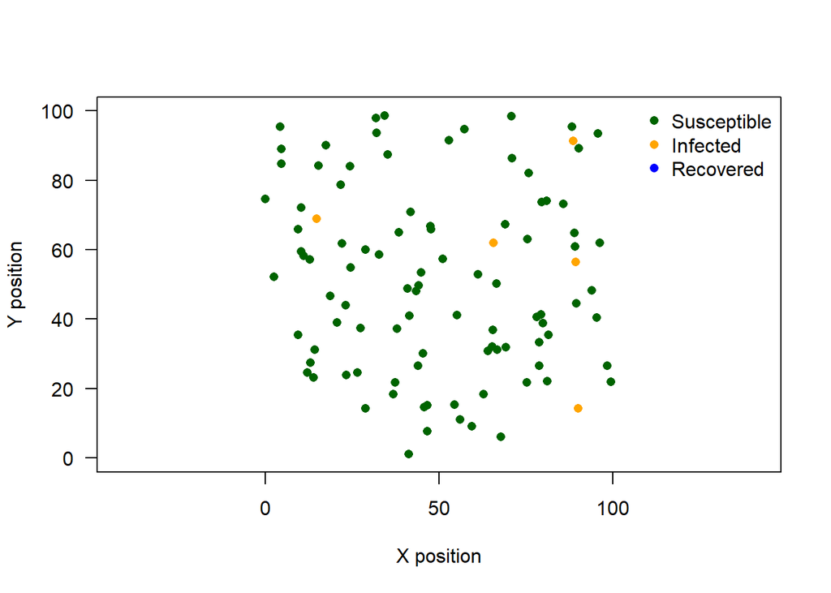

```r
cols=c("darkgreen","orange","blue")

plot(x_pos,y_pos, pch=16, col=cols[Status_sp[,1]+1],
     xlab="X position",  ylab="Y position",
     xlim=c(0,area_size),  ylim=c(0,area_size),
     asp=1, las=1)

legend("topright", legend=c("Susceptible","Infected","Recovered"),
       col=cols, pch=16, bty="n")
```

### Simulate spatial disease transmission

The recovery and loss-of-immunity processes remain identical to the previous individual-based model. The main difference is the transmission process: the infection probability is now calculated separately for each susceptible individual according to its distance from all currently infected individuals.

```r
for(i in 1:(nsteps-1)){

  # Keep previous status (<- optimise the code)
  Status_sp[,i+1]=Status_sp[,i]

  # 1. Loss of immunity: R -> S
  R_S=which(Status_sp[,i]==2)

  if(length(R_S)>0){
    LoI=rbinom(length(R_S),size=1,prob=theta)==1
    Status_sp[R_S[LoI],i+1]=0
  }

  # 2. Recovery: I -> R
  I_R=which(Status_sp[,i]==1)

  if(length(I_R)>0){
    GoI=rbinom(length(I_R),size=1,prob=gamma)==1
    Status_sp[I_R[GoI],i+1]=2
  }

  # 3. Spatial transmission: S -> I
  I=which(Status_sp[,i+1]==1)
  S=which(Status_sp[,i+1]==0)

  if(length(I)>0 & length(S)>0){

    for(id in S){

      # Distance from susceptible individual to all infected individuals
      d=Distance[id,I]

      # Transmission probability from each infected individual
      p_individual=beta*exp(-d/sigma)

      # Combined probability of infection
      p_inf=1-prod(1-p_individual)

      # Infection event
      Status_sp[id,i+1]=rbinom(1,size=1,prob=p_inf)
    }
  }
}
```

Unlike the previous homogeneous-mixing model, susceptible individuals can now experience very different infection risks depending on their spatial location. An individual surrounded by infected individuals will generally have a greater probability of infection than an individual located far away from them.

### Visualize the spatial epidemic

We can inspect the spatial distribution of the population at any point during the simulation.

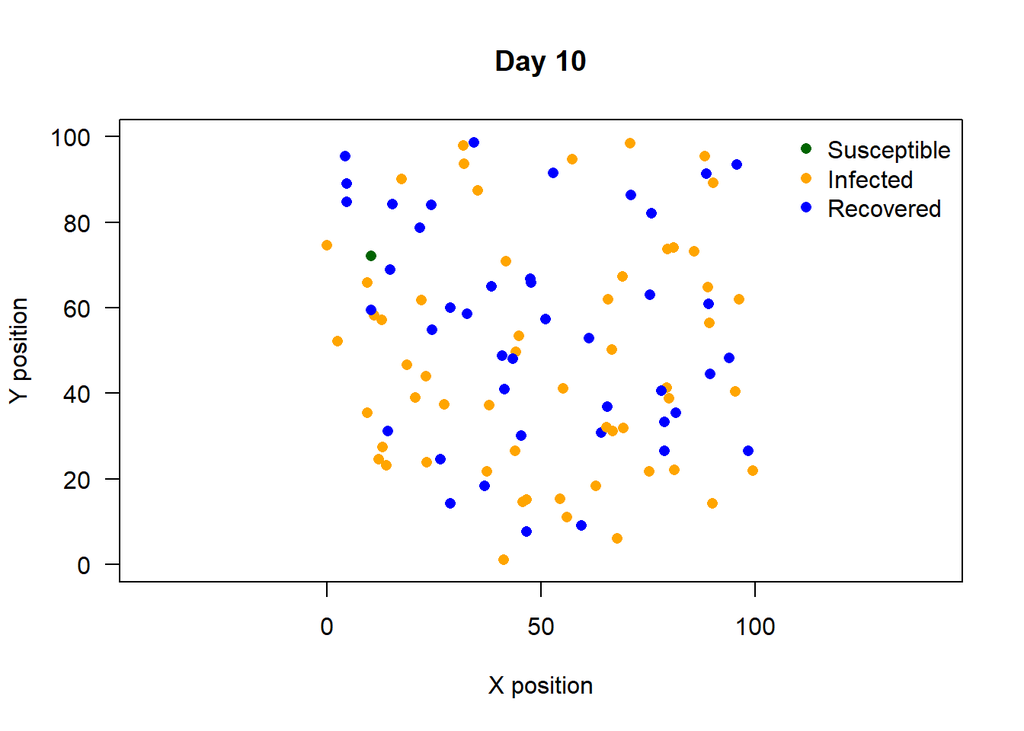

```r
day_plot=10

plot(x_pos,y_pos,
     pch=16,
     col=cols[Status_sp[,day_plot]+1],
     xlab="X position",
     ylab="Y position",
     xlim=c(0,area_size),
     ylim=c(0,area_size),
     asp=1,
     las=1,
     main=paste("Day",day_plot))

legend("topright",
       legend=c("Susceptible","Infected","Recovered"),
       col=cols,
       pch=16,
       bty="n")
```

Although transmission is determined at the individual and spatial levels, we can again summarize the results as population-level epidemic curves.

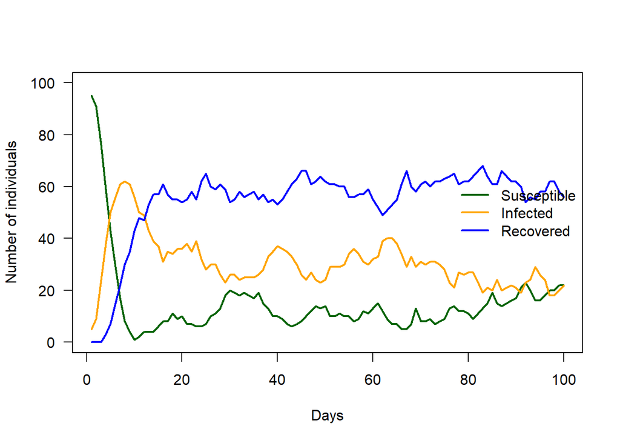

```r
S_total_sp=colSums(Status_sp==0)
I_total_sp=colSums(Status_sp==1)
R_total_sp=colSums(Status_sp==2)

plot(1:nsteps,S_total_sp,
     type="l",
     col="darkgreen",
     lwd=2,
     ylim=c(0,N),
     xlab="Days",
     ylab="Number of individuals",
     las=1)

lines(1:nsteps,I_total_sp,col="orange",lwd=2)
lines(1:nsteps,R_total_sp,col="blue",lwd=2)

legend("right",
       legend=c("Susceptible","Infected","Recovered"),
       col=c("darkgreen","orange","blue"),
       lwd=2,
       bty="n")
```

The main difference from the previous model is therefore not the disease states themselves, but *how susceptible individuals are exposed to infection*:

$$\text{Homogeneous mixing}
\quad\longrightarrow\quad
P(\text{infection}) \text{ depends on the total number of infected
individuals}$$

$$\text{Spatial transmission}
\quad\longrightarrow\quad
P(\text{infection}) \text{ depends on where infected individuals are
located}.$$

### Exercise 3: Exploring spatial disease transmission

Modify one element at a time and examine how the epidemic changes.

1. *Spatial transmission range (*$\sigma$).  
   Compare small and large values of `sigma`. How does the distance over which transmission can occur affect epidemic spread?
2. *Population density.*  
   Keep `N` constant but change `area_size`. How does concentrating the same population into a smaller area affect transmission?
3. *Initial location of infected individuals.*  
   Compare simulations where initially infected individuals are clustered in one area or distributed throughout the population. How does this affect disease spread?
4. *Movement.*  
   Instead of keeping the same $(x,y)$ coordinates throughout the simulation, generate new positions for the individuals at each time step. How does increasing spatial mixing affect the epidemic?:

### Want to try something different?

Try the interactive [Nergal game](https://thentrythis.org/projects/nergal/) developed by [Matthew Silk](https://mattjsilk.weebly.com/) and explore how disease transmission changes under different conditions.

*Can you beat Hector (🐘), Pablo (🐘), and Martin (🐬)?*

## Recommended literature

- Keeling, M.J. & Rohani, P. (2011). Modeling infectious diseases in humans and animals, Modeling Infectious Diseases in Humans and Animals. Princeton University press.
- Vynnycky, E. & White, R.G. (2010). [An introduction to infectious disease modelling](https://doi.org/10.1093/eurpub/ckq163). Oxford University Press.
- Kirkeby, C., Halasa, T., Gussmann, M., Toft, N., Græsbøll, K., 2017. [Methods for estimating disease transmission rates: Evaluating the precision of Poisson regression and two novel methods](https://doi.org/10.1038/s41598-017-09209-x). Scientific Reports.
- Zadoks, R.N., Allore, H.G., Hagenaars, T.J., Barkema, H.W., Schukken, Y.H., 2002. [A mathematical model of Staphylococcus aureus control in dairy herds](https://doi.org/10.1017/S0950268802007483). Epidemiol.
- Woudstra, S., Wente, N., Zhang, Y., Leimbach, S., Gussmann, M.K., Kirkeby, C. & Krömker, V., (2023). [Strain diversity and infection durations of Staphylococcus spp. and Streptococcus spp. causing intramammary infections in dairy cows](https://doi.org/10.3168/JDS.2022-22942). Journal of Dairy Science.